# 3B - Effect of CO2 on Sequence data

Orsolya Bajer-Molnar

2025-08-06

# Libraries and data

```r
library(ggplot2)
library(patchwork)
library(corrplot)
library(dplyr)
library(forcats)
library(ggpubr)
library(lubridate)
library(stringr)
library(tidyr)
library(tidyverse)
library(readr)
```

```
## spc_tbl_ [33 × 6] (S3: spec_tbl_df/tbl_df/tbl/data.frame)
##  $ school         : chr [1:33] "G" "G" "G" "G" ...
##  $ date.order     : num [1:33] 1 2 3 5 6 8 2 3 4 5 ...
##  $ richness       : num [1:33] 9 3 2 5 10 9 18 1 1 6 ...
##  $ Median_CO2     : num [1:33] NA NA NA 720 475 ...
##  $ Duration_high  : num [1:33] 0 0 0 680 331 ...
##  $ Duration_middle: num [1:33] 0 0 0 878 545 ...
##  - attr(*, "spec")=
##   .. cols(
##   ..   school = col_character(),
##   ..   date.order = col_double(),
##   ..   richness = col_double(),
##   ..   Median_CO2 = col_double(),
##   ..   Duration_high = col_double(),
##   ..   Duration_middle = col_double()
##   .. )
##  - attr(*, "problems")=<externalptr>
```

# Testing effects of CO2 on viral diversity

Since none of the metadata, including sample type had an effect on viral diverity (characterized by richness, see 2A and 2B), we merge data from all sample types for these analyses

I first test for collinearity among predictors (different measures of CO2)

```
##                 Median_CO2 Duration_high Duration_middle
## Median_CO2       1.0000000     0.7819523       0.8535162
## Duration_high    0.7819523     1.0000000       0.9051398
## Duration_middle  0.8535162     0.9051398       1.0000000
```

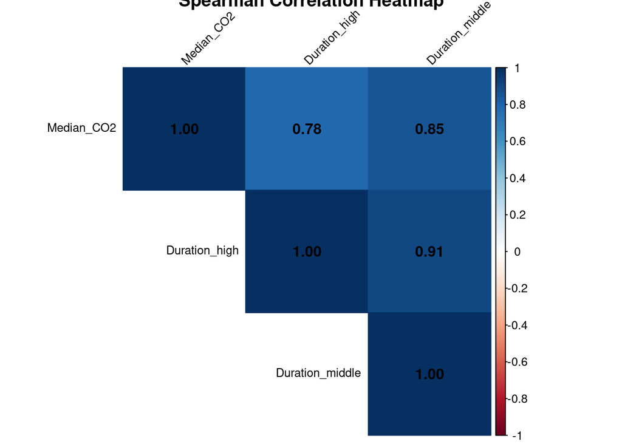

Since there is strong correlation, I will be testing effect in separate model to avoid interefence of collinerity

I then examine the distribution of the response variable, Viral richness

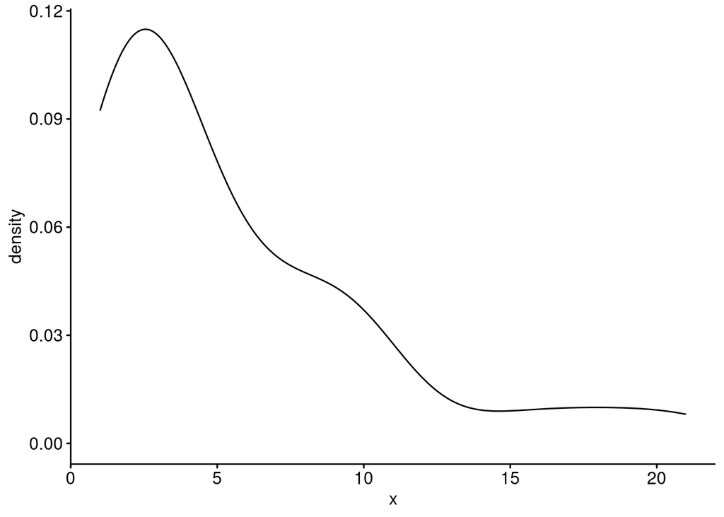

```r
ggdensity(DataDIVCO2$richness)
```

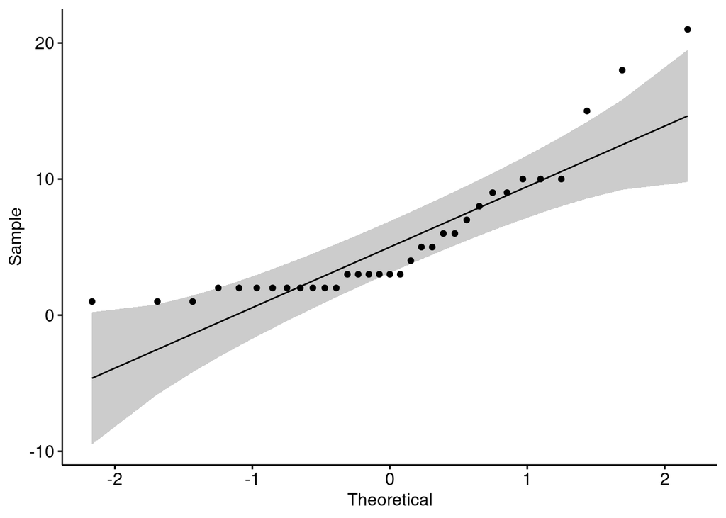

```r
ggqqplot(DataDIVCO2$richness)
```

## Median of CO2 levels

This model tests the effect of the median of the CO2 levels measured within 36 hours of the sample upload time

```r
richness_df_naomit<-na.omit(DataDIVCO2)
richness_median_mod<-glm(richness~Median_CO2+school, data= richness_df_naomit, family = Gamma(link='log'))
summary(richness_median_mod)
```

```
##
## Call:
## glm(formula = richness ~ Median_CO2 + school, family = Gamma(link = "log"),
##     data = richness_df_naomit)
##
## Coefficients:
##               Estimate Std. Error t value Pr(>|t|)
## (Intercept)  1.6000919  0.7767524   2.060   0.0542 .
## Median_CO2   0.0006297  0.0007755   0.812   0.4274
## schoolH     -0.4167954  0.5818701  -0.716   0.4830
## schoolK      0.3085971  0.7772222   0.397   0.6960
## schoolM      0.2825894  0.6956135   0.406   0.6894
## schoolR     -0.9749598  0.7382563  -1.321   0.2032
## schoolW     -0.8152173  0.8651688  -0.942   0.3585
## ---
## Signif. codes:  0 '***' 0.001 '**' 0.01 '*' 0.05 '.' 0.1 ' ' 1
##
## (Dispersion parameter for Gamma family taken to be 0.6749901)
##
##     Null deviance: 19.246  on 24  degrees of freedom
## Residual deviance: 13.948  on 18  degrees of freedom
## AIC: 145.33
##
## Number of Fisher Scoring iterations: 9
```

No significant effect detected

```r
richness_high_mod<-glm(richness~Duration_high+school, data= richness_df_naomit, family = Gamma(link='log'))
summary(richness_high_mod)
```

```
##
## Call:
## glm(formula = richness ~ Duration_high + school, family = Gamma(link = "log"),
##     data = richness_df_naomit)
##
## Coefficients:
##                 Estimate Std. Error t value Pr(>|t|)
## (Intercept)    1.6015909  0.6801078   2.355   0.0301 *
## Duration_high  0.0009076  0.0008930   1.016   0.3229
## schoolH       -0.3384578  0.5570506  -0.608   0.5510
## schoolK        0.3908393  0.8164723   0.479   0.6379
## schoolM        0.4532781  0.7394655   0.613   0.5476
## schoolR       -0.7906606  0.7846062  -1.008   0.3269
## schoolW       -0.7149295  0.8556574  -0.836   0.4144
## ---
## Signif. codes:  0 '***' 0.001 '**' 0.01 '*' 0.05 '.' 0.1 ' ' 1
##
## (Dispersion parameter for Gamma family taken to be 0.6122412)
##
##     Null deviance: 19.246  on 24  degrees of freedom
## Residual deviance: 13.558  on 18  degrees of freedom
## AIC: 144.56
##
## Number of Fisher Scoring iterations: 8
```

No significant effect detected

```r
richness_middle_mod<-glm(richness~Duration_middle+school, data= richness_df_naomit, family = Gamma(link='log'))
summary(richness_middle_mod)
```

```
##
## Call:
## glm(formula = richness ~ Duration_middle + school, family = Gamma(link = "log"),
##     data = richness_df_naomit)
##
## Coefficients:
##                   Estimate Std. Error t value Pr(>|t|)
## (Intercept)      1.3244558  0.7489150   1.768   0.0939 .
## Duration_middle  0.0008431  0.0006132   1.375   0.1860
## schoolH         -0.3381750  0.5667984  -0.597   0.5582
## schoolK          0.6615741  0.8656492   0.764   0.4546
## schoolM          0.7286109  0.8034602   0.907   0.3765
## schoolR         -0.5326079  0.8355444  -0.637   0.5319
## schoolW         -0.5108222  0.8733095  -0.585   0.5659
## ---
## Signif. codes:  0 '***' 0.001 '**' 0.01 '*' 0.05 '.' 0.1 ' ' 1
##
## (Dispersion parameter for Gamma family taken to be 0.6244851)
##
##     Null deviance: 19.246  on 24  degrees of freedom
## Residual deviance: 13.436  on 18  degrees of freedom
## AIC: 144.32
##
## Number of Fisher Scoring iterations: 7
```

No significant effect detected

## Area under CO2 curve

This model tests the effect of total CO2 exposure characterized by the area under the curve for CO2 measurements within 36 hours of the sample upload time

```r
setwd('~/LuPFiS/CO2')
DIV_CO2auc_df<-read_csv('Richness_CO2auc.csv')
DIV_CO2auc_df_naomit<-na.omit(DIV_CO2auc_df)
CO2_auc_mod<-glm(richness~auc+school, data= DIV_CO2auc_df_naomit, family = poisson(link='log'))
summary(CO2_auc_mod)
```

```
##
## Call:
## glm(formula = richness ~ auc + school, family = poisson(link = "log"),
##     data = DIV_CO2auc_df_naomit)
##
## Coefficients:
##               Estimate Std. Error z value Pr(>|z|)
## (Intercept)  1.930e+00  2.833e-01   6.814 9.49e-12 ***
## auc          1.440e-09  1.816e-09   0.793   0.4277
## schoolH     -3.111e-01  2.647e-01  -1.175   0.2398
## schoolK      1.374e-04  3.174e-01   0.000   0.9997
## schoolM      1.097e-01  2.975e-01   0.369   0.7123
## schoolR     -1.182e+00  4.083e-01  -2.894   0.0038 **
## schoolW     -1.078e+00  5.049e-01  -2.135   0.0328 *
## ---
## Signif. codes:  0 '***' 0.001 '**' 0.01 '*' 0.05 '.' 0.1 ' ' 1
##
## (Dispersion parameter for poisson family taken to be 1)
##
##     Null deviance: 104.958  on 24  degrees of freedom
## Residual deviance:  80.438  on 18  degrees of freedom
## AIC: 177.16
##
## Number of Fisher Scoring iterations: 5
```

No significant effect detected